# Week 6 Day 2 Homework

# MVP

## Question 1

```r
library(tidyverse)
library(janitor)
library(skimr)

phones <- read_csv("data/20190928-items.csv")
phones <- clean_names(phones)

skim(phones)
```

Data summary

| Name | phones |
| --- | --- |
| Number of rows | 792 |
| Number of columns | 9 |
| _______________________ |  |
| Column type frequency: |  |
| character | 7 |
| numeric | 2 |
| ________________________ |  |
| Group variables | None |

**Variable type: character**

| skim_variable | n_missing | complete_rate | min | max | empty | n_unique | whitespace |
| --- | --- | --- | --- | --- | --- | --- | --- |
| asin | 0 | 1.00 | 10 | 10 | 0 | 792 | 0 |
| brand | 0 | 1.00 | 4 | 8 | 0 | 10 | 0 |
| title | 0 | 1.00 | 19 | 200 | 0 | 785 | 0 |
| url | 0 | 1.00 | 60 | 97 | 0 | 792 | 0 |
| image | 0 | 1.00 | 87 | 87 | 0 | 719 | 0 |
| review_url | 0 | 1.00 | 49 | 49 | 0 | 792 | 0 |
| prices | 215 | 0.73 | 6 | 19 | 0 | 447 | 0 |

**Variable type: numeric**

| skim_variable | n_missing | complete_rate | mean | sd | p0 | p25 | p50 | p75 | p100 | hist |
| --- | --- | --- | --- | --- | --- | --- | --- | --- | --- | --- |
| rating | 0 | 1 | 3.61 | 0.67 | 1 | 3.2 | 3.7 | 4.00 | 5 | ▁▁▅▇▂ |
| total_reviews | 0 | 1 | 104.23 | 166.24 | 1 | 7.0 | 31.5 | 122.25 | 984 | ▇▁▁▁▁ |

The ratings appear to be on a 1-5 scale, the mean and median are similar.

The total reviews have very different mean and medians, I believe this means the data is skewed. It appears to be right skewed as mean > median and by comparing the values of p75 and p100 it looks like there are outliers towards the high numbers.

## Question 2

```r
phones %>%
  group_by(brand) %>%
  summarise(num_phones = n()) %>%
  slice_max(num_phones)
```

| brand | num_phones |
| --- | --- |
| Samsung | 397 |

Samsung has the highest number of phones at 397.

## Question 3

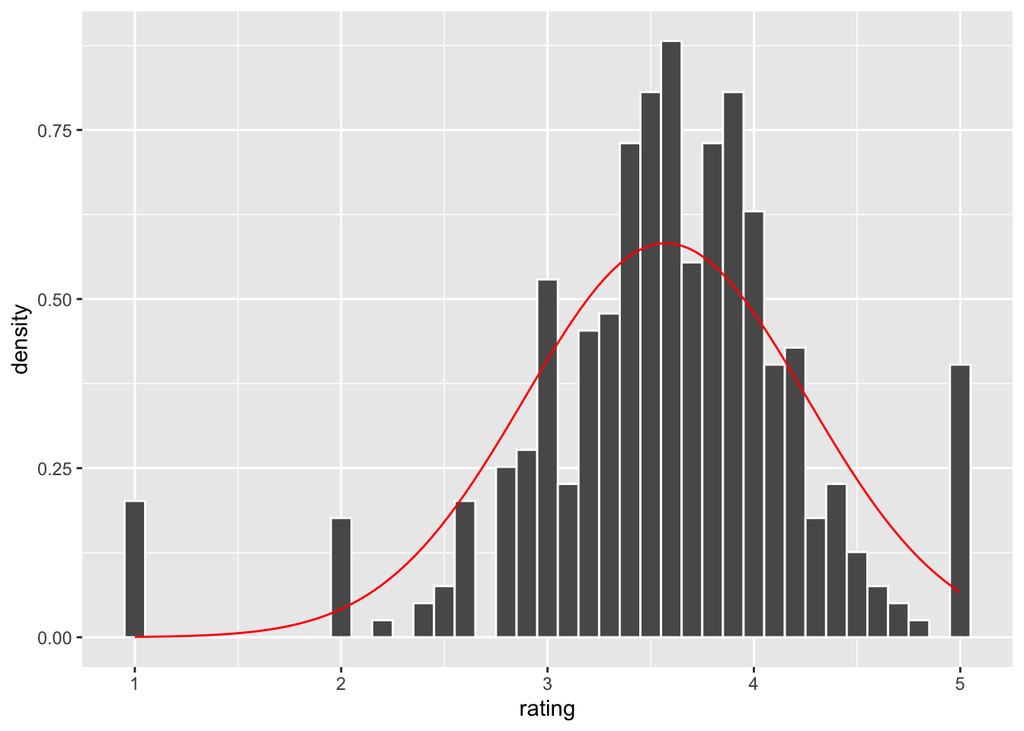

```r
phones_stats <- phones %>%
  filter(brand == "Samsung") %>%
  summarise(
    num = n(),
    mean = mean(rating),
    sd = sd(rating)
  )


phones %>%
  filter(brand == "Samsung") %>%
  ggplot(aes(x = rating)) +
  geom_histogram(aes(y = after_stat(density)),
                 col = "white",
                 binwidth = 0.1) +
  stat_function(
    fun = dnorm,
    args = list(
      mean = phones_stats$mean,
      sd = phones_stats$sd
    ),
    col = "red"
  )
```

The normal distribution appears to fit the data quite well, although there are some clear outliers at the high and low ends of the x scale.

## Question 4

sd = 0.6847859

```r
# ok to use nrow(phones) here as there are no missing ratings in the dataset

within_1_sd <- phones %>%
  filter(between(rating,
                 phones_stats$mean - phones_stats$sd,
                 phones_stats$mean + phones_stats$sd)) %>%
  summarise(n() / nrow(phones)) %>%
  pull()

within_2_sd <- phones %>%
  filter(between(rating,
                 phones_stats$mean - (2*phones_stats$sd),
                 phones_stats$mean + (2*phones_stats$sd))
         ) %>%
  summarise(n() / nrow(phones)) %>%
  pull()


within_3_sd <- phones %>%
  filter(between(rating,
                 phones_stats$mean - (3*phones_stats$sd),
                 phones_stats$mean + (3*phones_stats$sd))
         ) %>%
  summarise(n() / nrow(phones)) %>%
  pull()

normal_distr <- c(0.68, 0.95, 0.997)
Q4_distr <- c(within_1_sd, within_2_sd, within_3_sd)
how_many_sd <- c("within_1_sd", "within_2_sd", "within_3_sd")

comparison <-  tibble(how_many_sd,
                      "normal_distrbution" = normal_distr,
                      "Q4_distribution" = Q4_distr)

comparison
```

| how_many_sd | normal_distrbution | Q4_distribution |
| --- | --- | --- |
| within_1_sd | 0.680 | 0.7815657 |
| within_2_sd | 0.950 | 0.9330808 |
| within_3_sd | 0.997 | 0.9848485 |

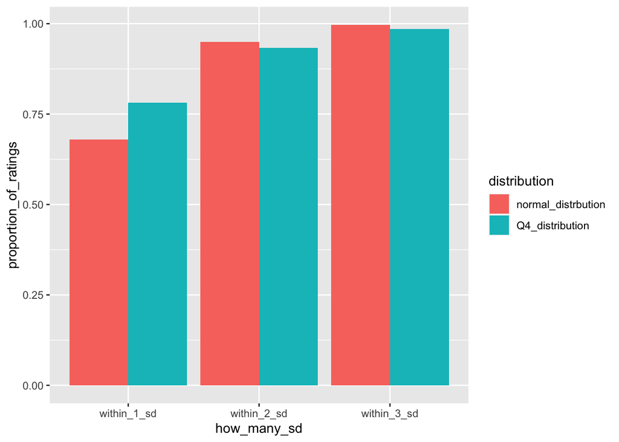

```r
comparison %>%
  pivot_longer(cols = 2:3, names_to = "distribution", values_to = "proportion_of_ratings") %>%
  ggplot(aes(x = how_many_sd, y = proportion_of_ratings)) +
  geom_col(aes(fill = distribution), position = "dodge")
```

The proportion of ratings found within 1 SD of the mean is 78%. This is higher than for a normal distribution where this figure is 68%. This suggests the distribution is narrower in shape and has a smaller standard deviation. A normal distribution has SD of 1 and our data has SD of 0.68 so this makes sense. The proportion of ratings found within 2 and 3 SDs of the mean are quite similar to a normal distribution.

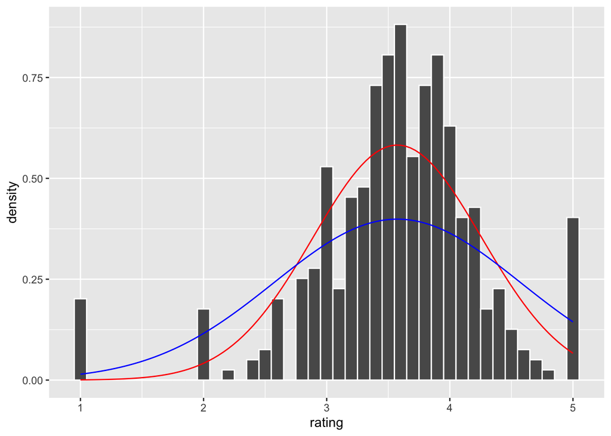

```r
phones %>%
  filter(brand == "Samsung") %>%
  ggplot(aes(x = rating)) +
  geom_histogram(aes(y = after_stat(density)),
                 col = "white",
                 binwidth = 0.1) +
  stat_function(
    fun = dnorm,
    args = list(
      mean = phones_stats$mean,
      sd = phones_stats$sd
    ),
    col = "red"
  ) +
  stat_function(
    fun = dnorm,
    args = list(
      mean = phones_stats$mean,
      sd = 1
    ),
    col = "blue"
  )
```

# 2 Extension

```r
library(ggpubr)
```

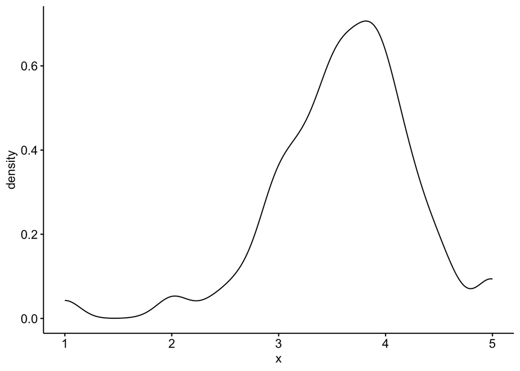

```r
ggdensity(phones$rating)
```

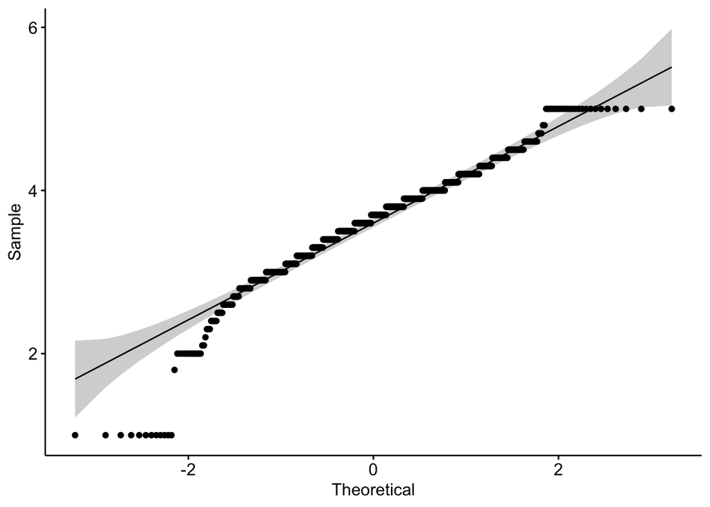

```r
ggqqplot(phones$rating)
```

```r
shapiro.test(phones$rating)
```

```
##
##  Shapiro-Wilk normality test
##
## data:  phones$rating
## W = 0.94494, p-value < 2.2e-16
```

Hmmm the website says p-value > 0.05 means distribution of data is not significantly different from normal distribution. Our data gives a tiny p-value which suggests the data is very different from a normal distribution. This is in contrary to what I deduced above in question 4.

## Alternative way using qqnorm

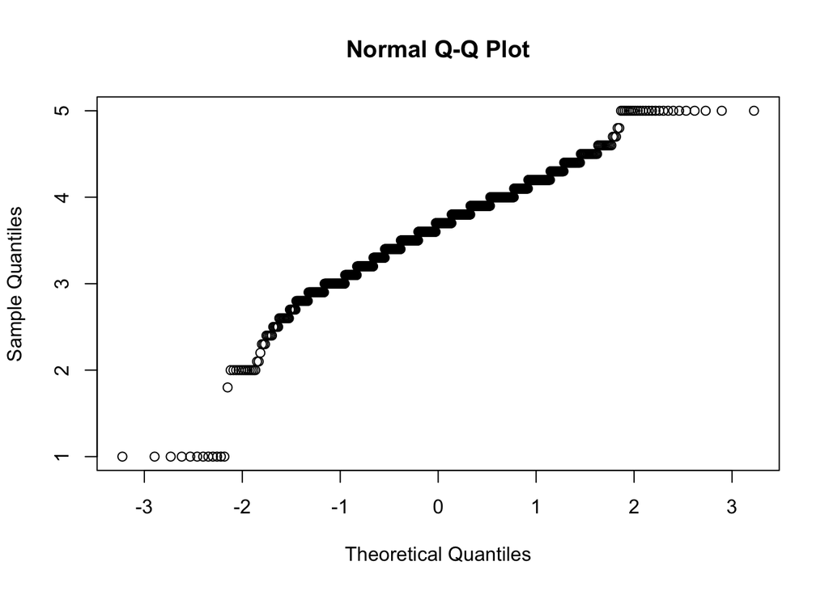

```r
qqnorm(phones$rating)
```

The line is straight in the middle but curves off at the end which can mean the data has more extreme values than would be expected in a nor mal distribution.